# Hurricane Dorain Temporal and Text Analysis

Joseph Holler

2025-01-09

# Set up environment

Previously installed packages

```r
#install.packages("tidyverse")
#install.packages("here")
#install.packages("tidytext")
```

Install new packages

```r
#install.packages("tm")
#install.packages("igraph")
#install.packages("ggraph")
```

Load packages

Check & create private data folder

```r
if(!dir.exists(here("data_private"))) {dir.create(here("data_private"))}
```

# Set up data

Create a file path for Dorian data

```r
# set file path
dorianFile <- here("data_private", "dorian_raw.RDS")
# show the file path
dorianFile
```

```
## [1] "C:/git/opengisci/wt25_josephholler/data_private/dorian_raw.RDS"
```

Check if Dorian data exists locally. If not, download the data.

```r
if(!file.exists(dorianFile)){
  download.file("https://geography.middlebury.edu/jholler/wt25/dorian/dorian_raw.RDS",
                dorianFile,
                mode="wb")
  }
```

Load Dorian data from RDS file

```r
dorian_raw <- readRDS(dorianFile)
```

View Dorian data column names

```r
dorian_columns <- colnames(dorian_raw)
```

Save Dorian data column names to a CSV file for documentation and reference

```r
write.csv(dorian_columns, here("dorian_columns.csv"))
```

# Explore data

Summarize place types

```r
count(dorian_raw, place_type)
```

```
## # A tibble: 6 × 2
##   place_type        n
##   <chr>         <int>
## 1 admin          2893
## 2 city          10462
## 3 country         346
## 4 neighborhood     43
## 5 poi             441
## 6 <NA>         195202
```

Graph Place types

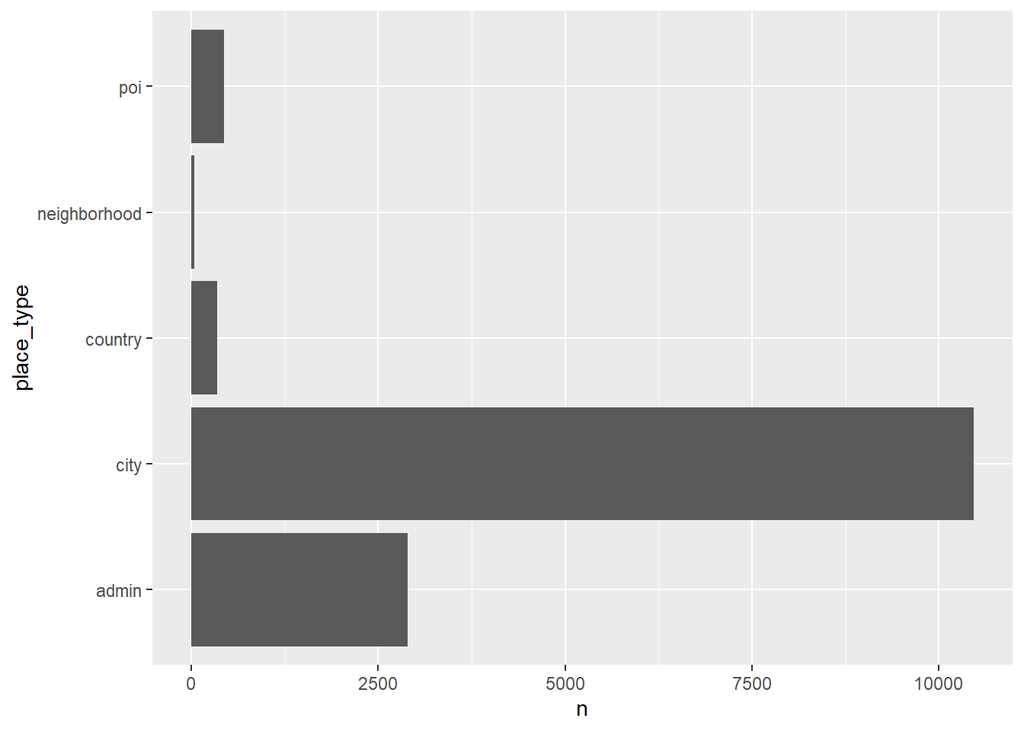

```r
dorian_raw |>
  filter(!is.na(place_type)) |>
  count(place_type) |>
  ggplot() +
  geom_col(aes(x = n, y = place_type))
```

# Graph temporal data

What data format is our `created_at` data using? Try the `str` function to reveal the structure of a data object. `$` picks out a column of a data frame by name

```r
str(dorian_raw$created_at)
```

```
##  POSIXct[1:209387], format: "2019-09-10 19:22:34" "2019-09-10 19:22:34" "2019-09-10 17:14:39" ...
```

Twitter data’s `created_at` column is in the `POSIXct` date-time format. Underneath the hood, all date-time data is stored as the number of seconds since January 1, 1970. We wrap that data around functions to transform it into human-readable formats. This format does not record a time zone and uses `UTC` for its time. Let’s convert that into local (EST) time for the majority of the region of interest using the `with_tz` function, part of the `lubridate` package that comes with tidyverse.

```r
dorian_est <- dorian_raw |>
  mutate(created_est = with_tz(created_at, tzone = "EST"))
```

Try graphing the tweets over time using `geom_histogram`. Once you get one graph working, keep copying the code into the subsequent block to make improvements.

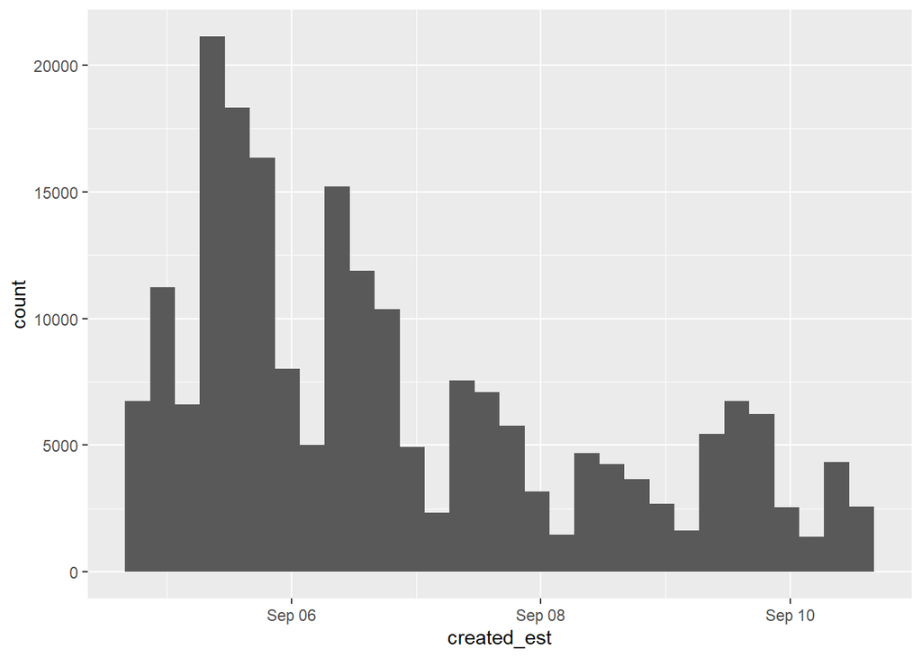

```r
dorian_est |>
  ggplot() +
  geom_histogram(aes(x = created_est))
```

How are the number of bins– and therefore the bin widths– defined?  
How is the x-axis formatted?

### Customize bin widths

To control bin widths,`geom_histogram` accepts a `binwidth` parameter assuming the units are in seconds. Try setting the bin width to one hour, and create the graph.

Try setting the bin width to 6-hour intervals, or even days.

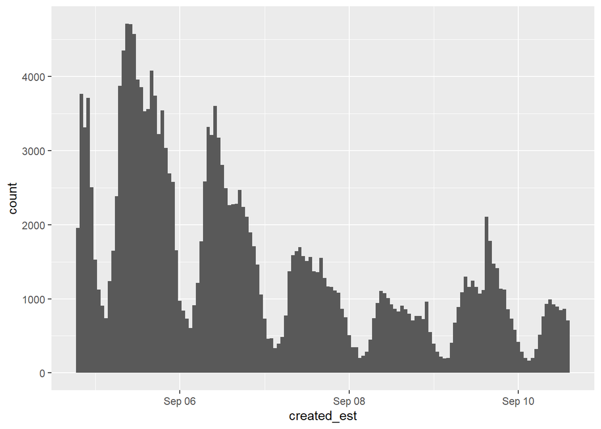

```r
dorian_est |>
  ggplot() +
  geom_histogram(aes(x = created_est), binwidth = 3600)
```

Reset the bin width to one hour (3600 seconds) before moving on.

### Customize a date-time axis

To control a date-time x-axis, try adding a `scale_x_datetime` function.

Add a `date_breaks` parameter with the value `"day"` to label and display grid lines for each day.

Add a `date_labels` parameter to format labels according to codes defined in `strptime`. Look up documentation with `?strptime`. Try `"%b-%d"` for a label with Month abbreviation and day.

Add a `name` parameter to customize the x-axis label.

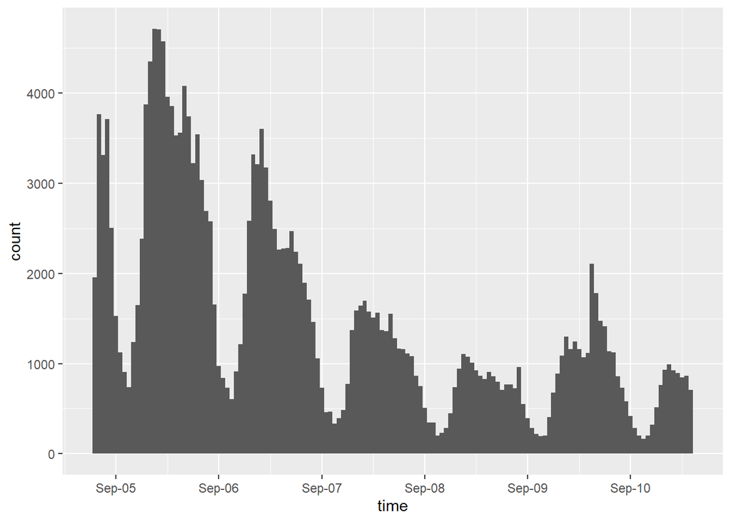

```r
dorian_est |>
  ggplot() +
  geom_histogram(aes(x = created_est), binwidth = 3600) +
  scale_x_datetime(date_breaks = "day",
                   date_labels = "%b-%d",
                   name = "time")
```

`scale_x_datetime` accepts a `limits` parameter as a list of two dates. You can create an eastern time zone date with `as.POSIXct("2019-09-05", tz="EST")`

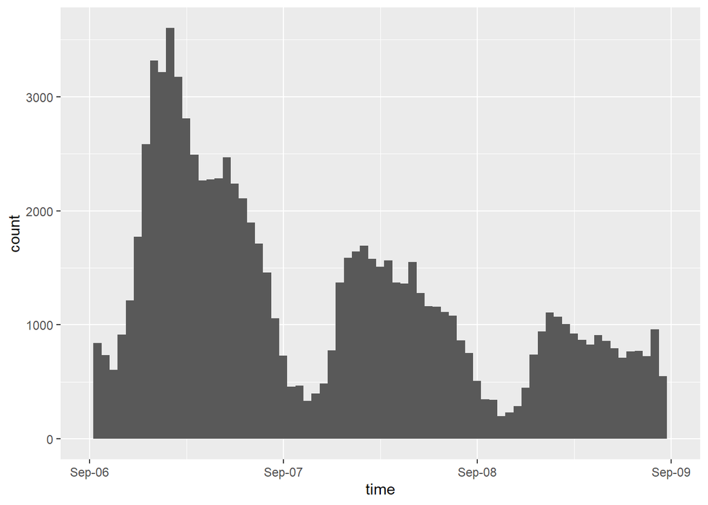

```r
dorian_est |>
  ggplot() +
  geom_histogram(aes(x = created_est), binwidth = 3600) +
  scale_x_datetime(date_breaks = "day",
                   date_labels = "%b-%d",
                   name = "time",
                   limits = c(as.POSIXct("2019-09-06", tz="EST"),
                              as.POSIXct("2019-09-09", tz="EST")
                              )
                   )
```

Finally, let’s remove the x-axis limits and switch from `geom_histogram` to `geom_freqpoly`

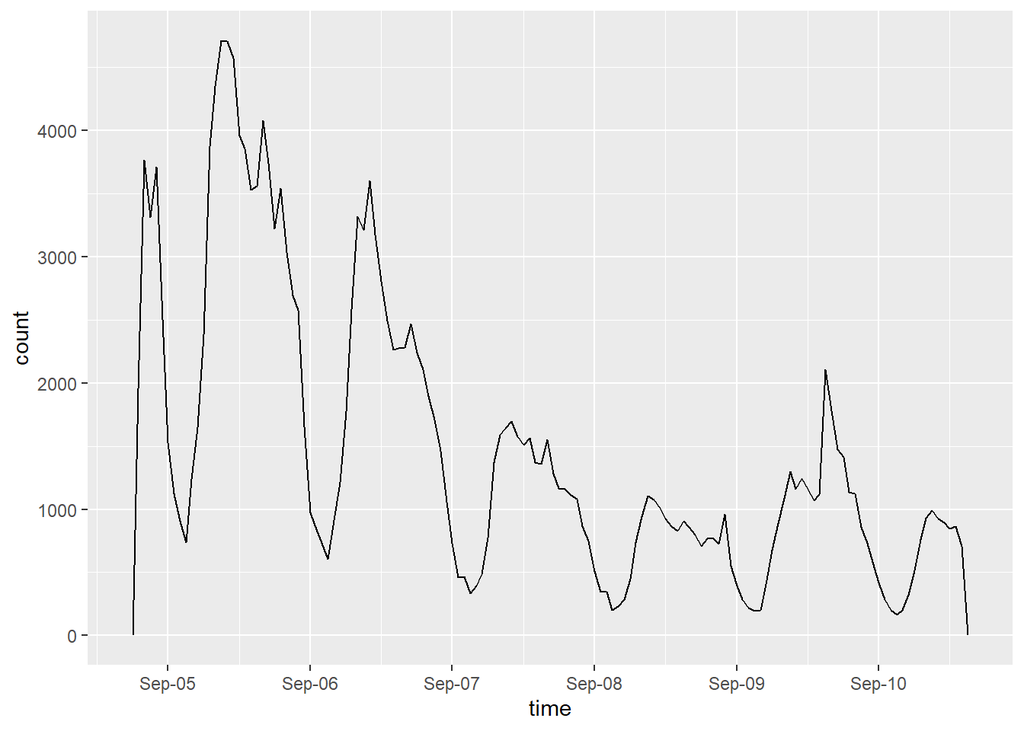

```r
dorian_est |>
  ggplot() +
  geom_freqpoly(aes(x = created_est), binwidth = 3600) +
  scale_x_datetime(date_breaks = "day",
                   date_labels = "%b-%d",
                   name = "time")
```

Can you describe the patterns in this data? Hint: Prof Holler did not start a Twitter query right away during the hurricane, and Twitter’s query only provides access to a few days of content.

# Text analysis

Prof Holler learned much of this workflow from https://www.earthdatascience.org/courses/earth-analytics/get-data-using-apis/text-mining-twitter-data-intro-r/

Tokenize the tweet content

```r
dorian_words <- dorian_raw |>
  select(status_id, text) |>
  unnest_tokens(input = text, output = word)
```

Query the most frequent words

```r
dorian_words |>
  count(word, sort = TRUE) |>
  head(15) |>
  mutate(word = reorder(word, n))
```

```
## # A tibble: 15 × 2
##    word           n
##    <fct>      <int>
##  1 the       167697
##  2 t.co      162688
##  3 https     162663
##  4 hurricane 115951
##  5 to        108686
##  6 dorian    108422
##  7 a          82802
##  8 of         69985
##  9 and        66995
## 10 in         64506
## 11 is         50188
## 12 for        42596
## 13 on         37768
## 14 you        34658
## 15 i          30498
```

What are stop words? Let’s see a sample of 10 `stop_words`

```r
stop_words |> sample_n(10)
```

```
## # A tibble: 10 × 2
##    word       lexicon
##    <chr>      <chr>
##  1 will       onix
##  2 presenting onix
##  3 be         snowball
##  4 would      onix
##  5 ended      onix
##  6 o          SMART
##  7 they've    snowball
##  8 whom       SMART
##  9 thing      onix
## 10 gets       onix
```

Remove stop words using the `filter` function for when `word` is not in the list of stop words.

```r
dorian_words_cleaned <- dorian_words |>
  filter(!(word %in% stop_words$word))
```

Remove search terms and junk words. First, make a `junk` list of such words.

```r
junk <- c("hurricane",
          "sharpiegate",
          "dorian",
          "t.co",
          "https",
          "amp",
          "de",
          "hurricanedorian")

dorian_words_cleaned <- dorian_words_cleaned |>
  filter(!(word %in% junk))
```

Repeat our query to display the most frequent words.

```r
dorian_words_cleaned |>
  count(word, sort = TRUE) |>
  head(15) |>
  mutate(word = reorder(word, n))
```

```
## # A tibble: 15 × 2
##    word                n
##    <fct>           <int>
##  1 bahamas         25366
##  2 trump           22292
##  3 alabama         20282
##  4 realdonaldtrump 15266
##  5 storm           12088
##  6 people          11144
##  7 hit              9064
##  8 carolina         8187
##  9 map              8168
## 10 coast            7713
## 11 news             7495
## 12 weather          7454
## 13 florida          7216
## 14 north            7095
## 15 noaa             6928
```

Should any more words be removed? If so, add them to the `junk` vector and repeat the two code blocks above.

## Graph frequencies of words

Do you remember how to make a horizontal bar chart with the frequencies of words, having the most common word on the top?

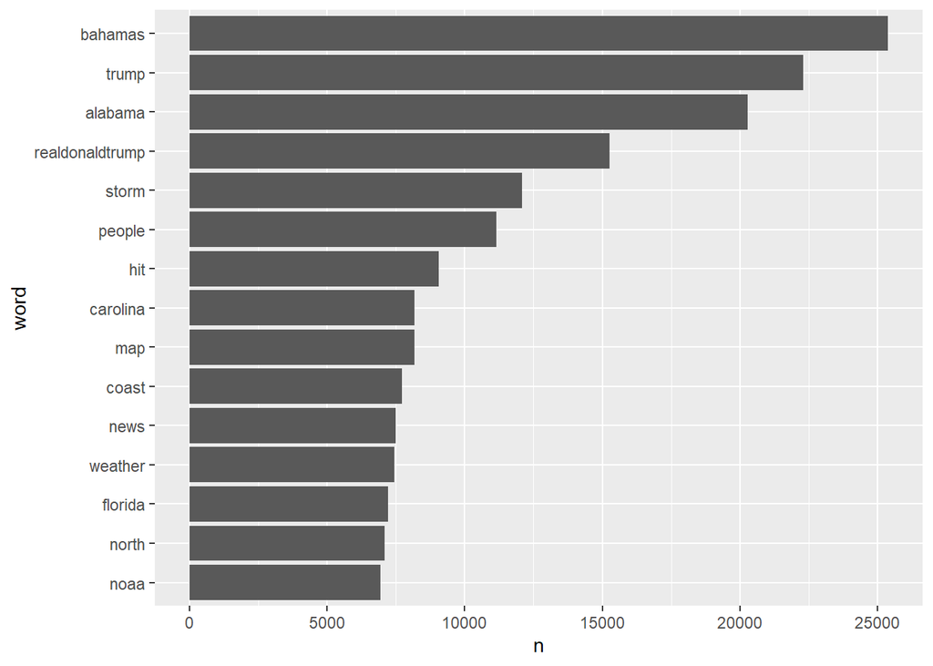

```r
dorian_words_cleaned |>
  count(word, sort = TRUE) |>
  head(15) |>
  mutate(word = reorder(word, n)) |>
  ggplot() +
  geom_col(aes(x = n, y = word))
```

### Bonus: try making a word cloud

https://towardsdatascience.com/create-a-word-cloud-with-r-bde3e7422e8a

## Analyze and graph word assoctiation

create n-gram data structure n-grams create pairs of co-located words wrapper function: unnest_ngrams skip_ngrams forms pairs separated by a defined distance

For this to work, we need to remove stop words and other junk from the text *before* we unnest tokens. The `tm` package has a handy `removeWords` function for this, producing text string data *without* the undesired text content.

This is a time-consuming process that does not need the other data columns, so we can `select` from `dorian` only the `text` column with `select(text)`.

`Select` is a very powerful function for selecting subsets of columns.

We’ll also use a `tolower` function to convert everything to lower-case for more straightforward text comparison.

```r
# separate words and count frequency of word pair occurrence in tweets
dorian_text_cleaned <- dorian_raw |>
  select(text) |>
  mutate(text_clean = removeWords(tolower(text), stop_words$word),
         text_clean = removeWords(text_clean, junk))
```

Sample the resulting text data to see what it looks like. Do you remember how? If we have a sample function in a code block, we can re-run the code block to randomly sample something different.

```r
dorian_text_cleaned |> sample_n(1)
```

```
## # A tibble: 1 × 2
##   text                                                                text_clean
##   <chr>                                                               <chr>
## 1 @BoceWright @TonyElder08 Sorry, maybe I misunderstood. I just did … @bocewrig…
```

If you’re satisfied with the results, let’s mimic the `unnest_tokens` function we used previously, adding a `token = "ngrams` parameter.

```r
# separate words and count frequency of word pair occurrence in tweets
dorian_ngrams <- dorian_text_cleaned |>
  unnest_tokens(output = paired_words,
                input = text_clean,
                token = "ngrams")

head(dorian_ngrams, 5)
```

```
## # A tibble: 5 × 2
##   text                                                              paired_words
##   <chr>                                                             <chr>
## 1 Michael Jordan is donating $1MILLION to hurricane relief in Baha… michael jor…
## 2 Michael Jordan is donating $1MILLION to hurricane relief in Baha… jordan dona…
## 3 Michael Jordan is donating $1MILLION to hurricane relief in Baha… donating 1m…
## 4 Michael Jordan is donating $1MILLION to hurricane relief in Baha… 1million re…
## 5 Michael Jordan is donating $1MILLION to hurricane relief in Baha… relief baha…
```

Now, we’ll `separate` the paired_words column into two separate columns so that we can count up the unique pairs.

```r
# separate words and count frequency of word pair occurrence in tweets
dorian_pairs <- dorian_ngrams |>
  separate(paired_words, c("word1", "word2"), sep = " ") |>
  count(word1, word2, sort = TRUE)
head(dorian_pairs, 5)
```

```
## # A tibble: 5 × 3
##   word1 word2        n
##   <chr> <chr>    <int>
## 1 <NA>  <NA>     13390
## 2 north carolina  4791
## 3 south carolina  2359
## 4 death toll      2014
## 5 outer banks     1948
```

```r
# graph a word cloud with space indicating association.
# you may change the filter to filter more or less than pairs with 25 instances
dorian_word_graph <- dorian_pairs |>
  filter(n >= 900 & !is.na(word1) & !is.na(word2)) |>
  graph_from_data_frame()
```

Graph it! The `ggraph` function builds upon `ggplot` to graph… well, graph data. Much like `ggplot`, just about everything about the graph can be customized.

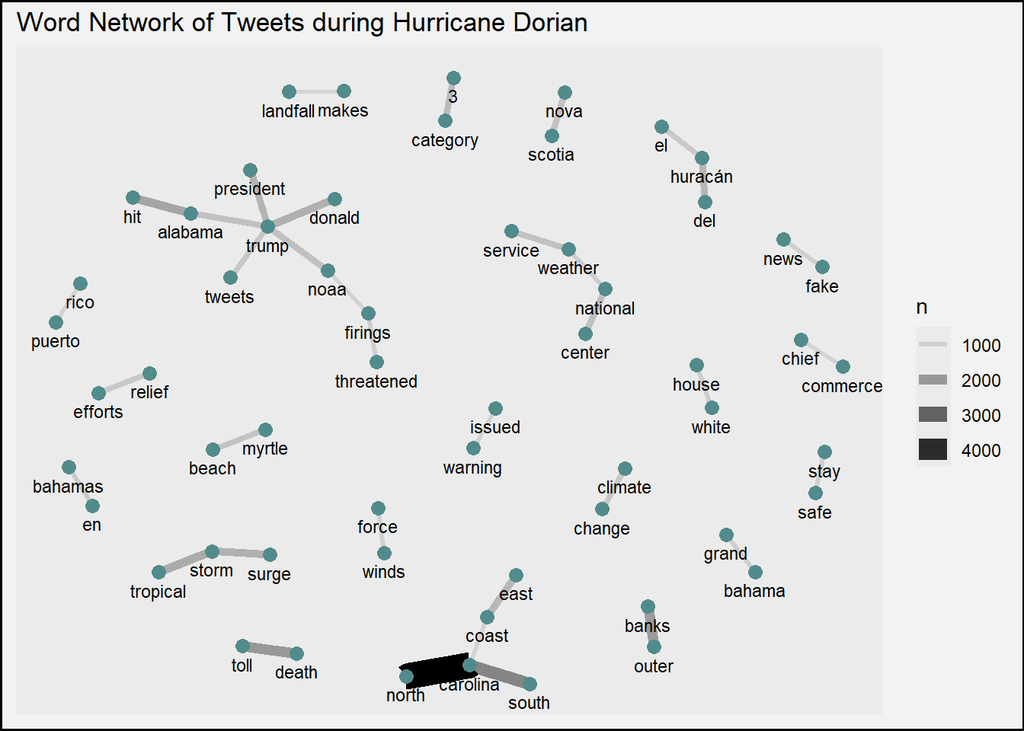

```r
# graph a word cloud with space indicating association.
# you may change the filter to filter more or less than pairs with 25 instances
dorian_word_graph |> ggraph(layout = "fr") +
  geom_edge_link(aes(edge_alpha = n, edge_width = n)) +
  geom_node_point(color = "darkslategray4", size = 3) +
  geom_node_text(aes(label = name), vjust = 1.8, size = 3) +
  labs(
    title = "Word Network of Tweets during Hurricane Dorian",
    x = "", y = ""
  ) +
  theme(
    plot.background = element_rect(
    fill = "grey95",
    colour = "black",
    size = 1
    ),
    legend.background = element_rect(fill = "grey95")
  )
```

If the graph is too busy, try increasing the filter for number of occurrences. If the graph is too simple, try decreasing the filter for the number of occurrences.

The end!